# Wealth Indicators V2

Author

MK

This document is a summary of assets and household characteristics of the PATHOME study. Included are two methods of classifying households based on their assets: a Wealth Index, which is a numeric variable which summarizes each households assets, and a cluster number, which groups households into groups based on their assets. All data is from the Household Survey.

# General Information about Assets and Household Characterisitcs.

|  | Kisumu Low (N=70) | Kisumu Middle (N=74) | Nairobi Low (N=67) | Nairobi Middle (N=69) | Overall Low (N=137) | Overall Middle (N=143) |
| --- | --- | --- | --- | --- | --- | --- |
| Age (3 Month Bins) |  |  |  |  |  |  |
| (0,90] | 18 (25.7%) | 22 (29.7%) | 14 (20.9%) | 13 (18.8%) | 32 (23.4%) | 35 (24.5%) |
| (90,180] | 16 (22.9%) | 19 (25.7%) | 13 (19.4%) | 20 (29.0%) | 29 (21.2%) | 39 (27.3%) |
| (180,270] | 15 (21.4%) | 20 (27.0%) | 16 (23.9%) | 16 (23.2%) | 31 (22.6%) | 36 (25.2%) |
| (270,360] | 21 (30.0%) | 13 (17.6%) | 24 (35.8%) | 20 (29.0%) | 45 (32.8%) | 33 (23.1%) |
| Education |  |  |  |  |  |  |
| Primary | 22 (31.4%) | 6 (8.1%) | 29 (43.3%) | 12 (17.4%) | 51 (37.2%) | 18 (12.6%) |
| Secondary | 38 (54.3%) | 27 (36.5%) | 31 (46.3%) | 37 (53.6%) | 69 (50.4%) | 64 (44.8%) |
| At Least College | 10 (14.3%) | 41 (55.4%) | 7 (10.4%) | 20 (29.0%) | 17 (12.4%) | 61 (42.7%) |
| Occupation |  |  |  |  |  |  |
| Market vendor | 26 (37.1%) | 19 (25.7%) | 13 (19.4%) | 7 (10.1%) | 39 (28.5%) | 26 (18.2%) |
| Child Care | 2 (2.9%) | 4 (5.4%) | 1 (1.5%) | 35 (50.7%) | 3 (2.2%) | 39 (27.3%) |
| Casual worker | 7 (10.0%) | 5 (6.8%) | 43 (64.2%) | 15 (21.7%) | 50 (36.5%) | 20 (14.0%) |
| Professional | 6 (8.6%) | 15 (20.3%) | 3 (4.5%) | 7 (10.1%) | 9 (6.6%) | 22 (15.4%) |
| Other | 29 (41.4%) | 31 (41.9%) | 7 (10.4%) | 5 (7.2%) | 36 (26.3%) | 36 (25.2%) |
| Income |  |  |  |  |  |  |
| Below 10, 000 Kshs | 35 (50.0%) | 30 (40.5%) | 57 (85.1%) | 20 (29.0%) | 92 (67.2%) | 50 (35.0%) |
| 10, 001-20, 000 Kshs | 29 (41.4%) | 19 (25.7%) | 8 (11.9%) | 27 (39.1%) | 37 (27.0%) | 46 (32.2%) |
| 20, 000-30,000 Kshs | 5 (7.1%) | 14 (18.9%) | 2 (3.0%) | 15 (21.7%) | 7 (5.1%) | 29 (20.3%) |
| 30,001-40,000 Kshs | 0 (0%) | 5 (6.8%) | 0 (0%) | 2 (2.9%) | 0 (0%) | 7 (4.9%) |
| 40,001-50,000 Kshs | 0 (0%) | 2 (2.7%) | 0 (0%) | 1 (1.4%) | 0 (0%) | 3 (2.1%) |
| 50,001 and above | 1 (1.4%) | 4 (5.4%) | 0 (0%) | 4 (5.8%) | 1 (0.7%) | 8 (5.6%) |
| Own Or Rent |  |  |  |  |  |  |
| Own | 10 (14.3%) | 2 (2.7%) | 14 (20.9%) | 6 (8.7%) | 24 (17.5%) | 8 (5.6%) |
| Rent | 60 (85.7%) | 72 (97.3%) | 53 (79.1%) | 63 (91.3%) | 113 (82.5%) | 135 (94.4%) |
| Kitchen Location |  |  |  |  |  |  |
| In a separate room | 44 (62.9%) | 39 (52.7%) | 4 (6.0%) | 25 (36.2%) | 48 (35.0%) | 64 (44.8%) |
| In another room in the compound | 2 (2.9%) | 1 (1.4%) | 2 (3.0%) | 2 (2.9%) | 4 (2.9%) | 3 (2.1%) |
| In the corner of the main room | 21 (30.0%) | 33 (44.6%) | 61 (91.0%) | 42 (60.9%) | 82 (59.9%) | 75 (52.4%) |
| Outside in the compound yard | 3 (4.3%) | 1 (1.4%) | 0 (0%) | 0 (0%) | 3 (2.2%) | 1 (0.7%) |

[output cut: 90 more lines]

# Wealth Index Calculation

The wealth index was calculated by taking the first component of the PCA (values which summarize the most significant patters found among all the variables, in this case, wealth), and centering/scaling the values to be bounded by 0 and 10.

## PCA Diagnositic Plots

**Scree Plot**

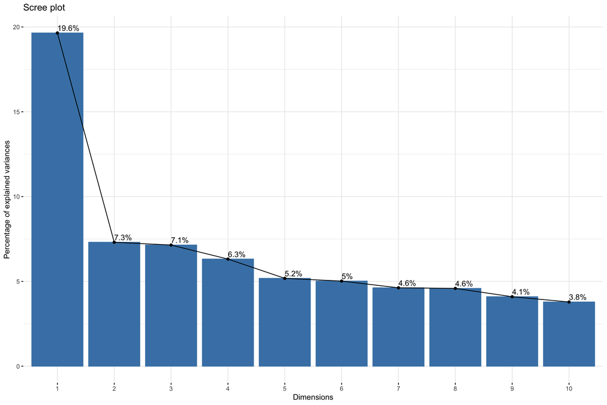

**PCA Biplot: Dim-1 vs Dim-2 Without Transformation**

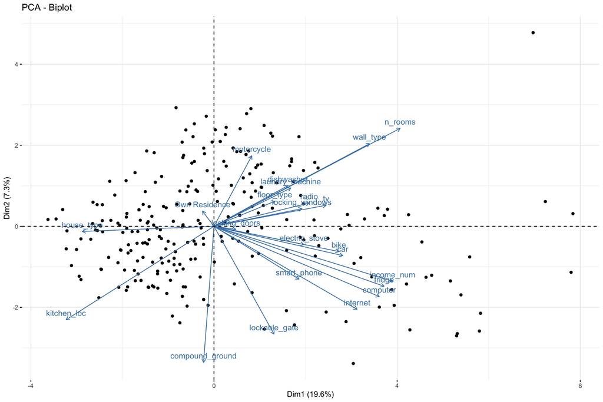

**Dim-1 Contribution**

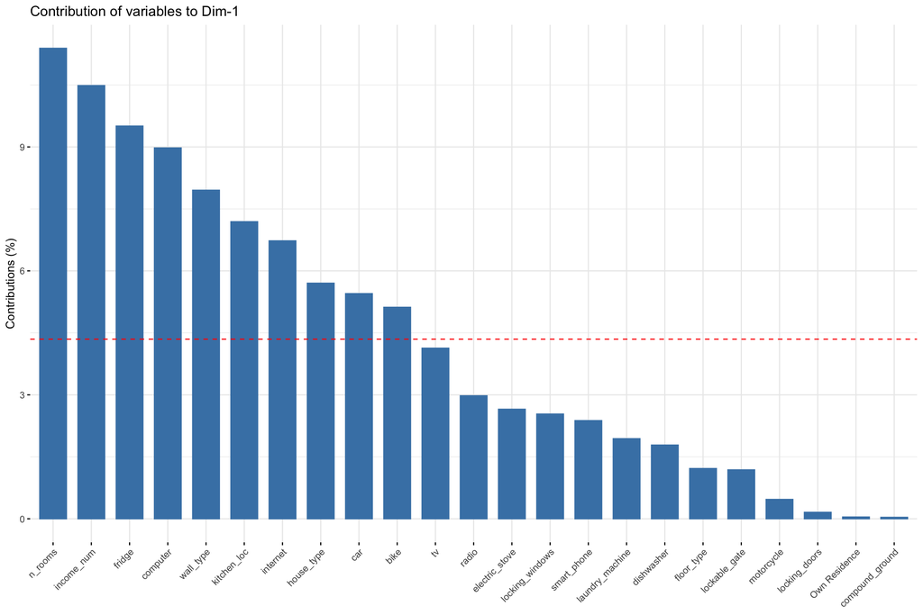

## Adjusted Wealth Score

Removed any variables that may be tested for pathogen stuides.

**Scree Plot**

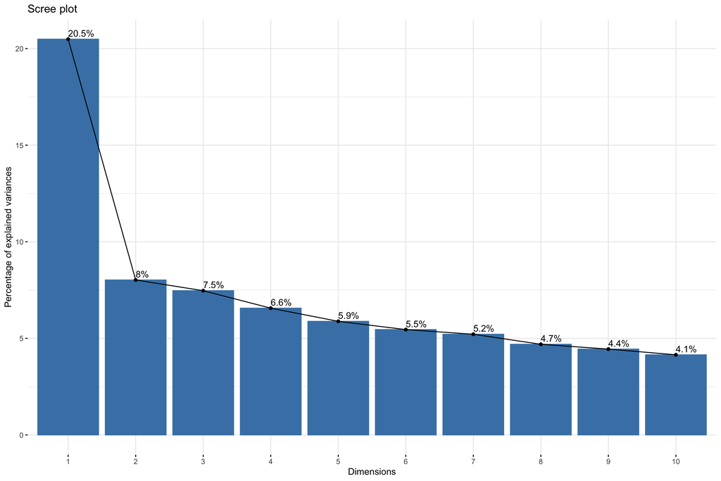

**PCA Biplot: Dim-1 vs Dim-2 Without Transformation**

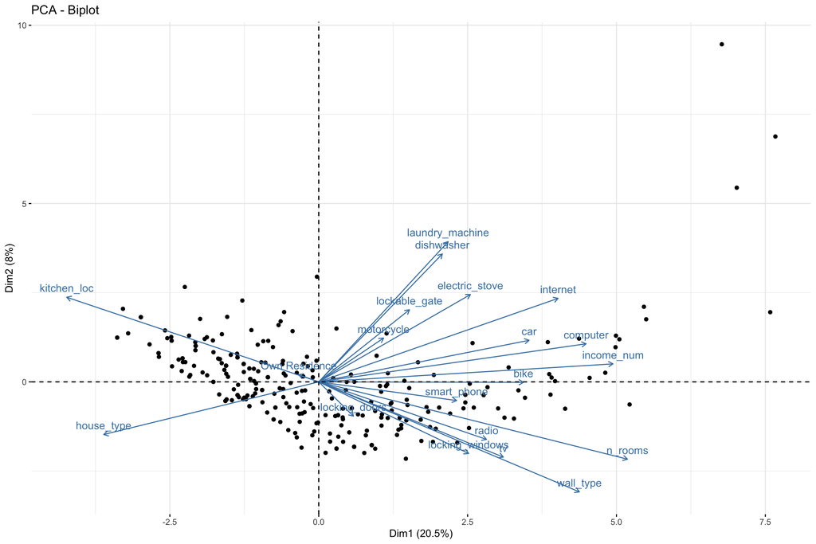

**Dim-1 Contribution**

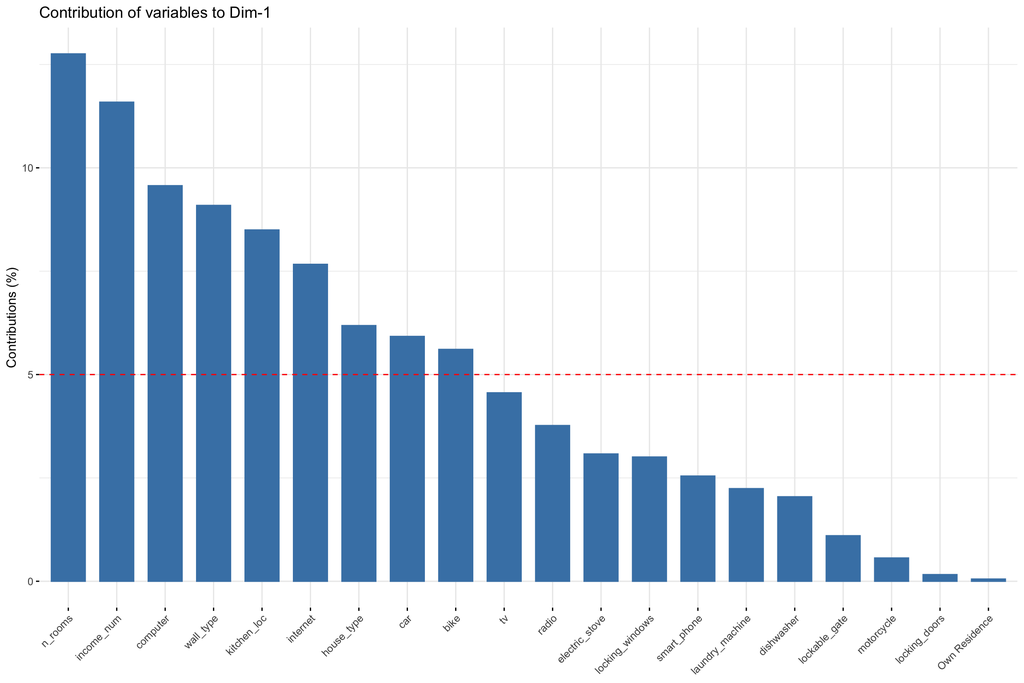

## Wealth Score Vizualization

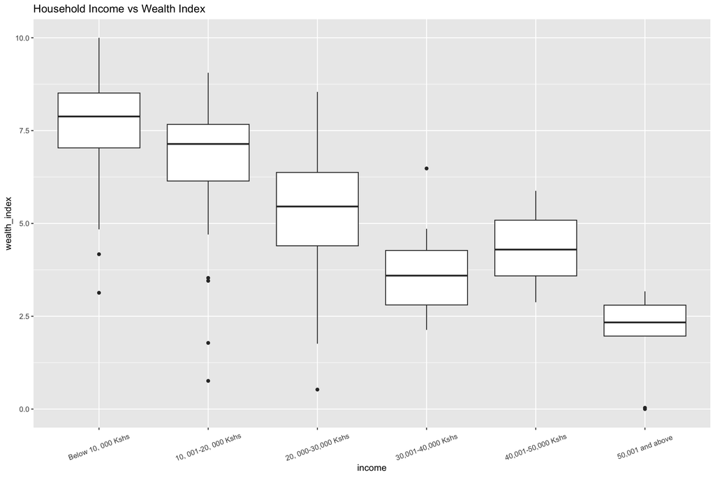

## Table of Assets (and other important hh charactersitics) by Wealth Index Quartile

|  | WI: Q1 (N=70) | WI: Q2 (N=70) | WI: Q3 (N=70) | WI: Q4 (N=70) |
| --- | --- | --- | --- | --- |
| Age (3 Month Bins) |  |  |  |  |
| (0,90] | 10 (14.3%) | 20 (28.6%) | 19 (27.1%) | 18 (25.7%) |
| (90,180] | 18 (25.7%) | 19 (27.1%) | 16 (22.9%) | 15 (21.4%) |
| (180,270] | 21 (30.0%) | 8 (11.4%) | 16 (22.9%) | 22 (31.4%) |
| (270,360] | 21 (30.0%) | 23 (32.9%) | 19 (27.1%) | 15 (21.4%) |
| City |  |  |  |  |
| Kisumu | 43 (61.4%) | 51 (72.9%) | 24 (34.3%) | 26 (37.1%) |
| Nairobi | 27 (38.6%) | 19 (27.1%) | 46 (65.7%) | 44 (62.9%) |
| Nbhd_ses |  |  |  |  |
| Low | 12 (17.1%) | 41 (58.6%) | 36 (51.4%) | 48 (68.6%) |
| Middle | 58 (82.9%) | 29 (41.4%) | 34 (48.6%) | 22 (31.4%) |
| Income |  |  |  |  |
| Below 10, 000 Kshs | 14 (20.0%) | 28 (40.0%) | 40 (57.1%) | 60 (85.7%) |
| 10, 001-20, 000 Kshs | 17 (24.3%) | 31 (44.3%) | 28 (40.0%) | 7 (10.0%) |
| 20, 000-30,000 Kshs | 21 (30.0%) | 10 (14.3%) | 2 (2.9%) | 3 (4.3%) |
| 30,001-40,000 Kshs | 6 (8.6%) | 1 (1.4%) | 0 (0%) | 0 (0%) |
| 40,001-50,000 Kshs | 3 (4.3%) | 0 (0%) | 0 (0%) | 0 (0%) |
| 50,001 and above | 9 (12.9%) | 0 (0%) | 0 (0%) | 0 (0%) |
| Own Or Rent |  |  |  |  |
| Own | 7 (10.0%) | 9 (12.9%) | 10 (14.3%) | 6 (8.6%) |
| Rent | 63 (90.0%) | 61 (87.1%) | 60 (85.7%) | 64 (91.4%) |
| Kitchen Location |  |  |  |  |
| In a separate room | 60 (85.7%) | 42 (60.0%) | 9 (12.9%) | 1 (1.4%) |
| In another room in the compound | 2 (2.9%) | 2 (2.9%) | 3 (4.3%) | 0 (0%) |
| In the corner of the main room | 7 (10.0%) | 26 (37.1%) | 57 (81.4%) | 67 (95.7%) |
| Outside in the compound yard | 1 (1.4%) | 0 (0%) | 1 (1.4%) | 2 (2.9%) |
| Wall Type |  |  |  |  |
| Cement blocks or bricks | 67 (95.7%) | 55 (78.6%) | 29 (41.4%) | 5 (7.1%) |
| non-cement | 3 (4.3%) | 15 (21.4%) | 41 (58.6%) | 65 (92.9%) |
| Compound Ground |  |  |  |  |

[output cut: 76 more lines]

## Table of Assets (and other important hh charactersitics) by Adjusted Wealth Index Quartile

|  | WI: Q1 (N=70) | WI: Q2 (N=70) | WI: Q3 (N=71) | WI: Q4 (N=69) |
| --- | --- | --- | --- | --- |
| Age (3 Month Bins) |  |  |  |  |
| (0,90] | 10 (14.3%) | 24 (34.3%) | 15 (21.1%) | 18 (26.1%) |
| (90,180] | 18 (25.7%) | 19 (27.1%) | 14 (19.7%) | 17 (24.6%) |
| (180,270] | 20 (28.6%) | 8 (11.4%) | 17 (23.9%) | 22 (31.9%) |
| (270,360] | 22 (31.4%) | 19 (27.1%) | 25 (35.2%) | 12 (17.4%) |
| City |  |  |  |  |
| Kisumu | 42 (60.0%) | 55 (78.6%) | 22 (31.0%) | 25 (36.2%) |
| Nairobi | 28 (40.0%) | 15 (21.4%) | 49 (69.0%) | 44 (63.8%) |
| Nbhd_ses |  |  |  |  |
| Low | 12 (17.1%) | 43 (61.4%) | 36 (50.7%) | 46 (66.7%) |
| Middle | 58 (82.9%) | 27 (38.6%) | 35 (49.3%) | 23 (33.3%) |
| Income |  |  |  |  |
| Below 10, 000 Kshs | 13 (18.6%) | 31 (44.3%) | 39 (54.9%) | 59 (85.5%) |
| 10, 001-20, 000 Kshs | 18 (25.7%) | 28 (40.0%) | 30 (42.3%) | 7 (10.1%) |
| 20, 000-30,000 Kshs | 21 (30.0%) | 10 (14.3%) | 2 (2.8%) | 3 (4.3%) |
| 30,001-40,000 Kshs | 6 (8.6%) | 1 (1.4%) | 0 (0%) | 0 (0%) |
| 40,001-50,000 Kshs | 3 (4.3%) | 0 (0%) | 0 (0%) | 0 (0%) |
| 50,001 and above | 9 (12.9%) | 0 (0%) | 0 (0%) | 0 (0%) |
| Own Or Rent |  |  |  |  |
| Own | 7 (10.0%) | 9 (12.9%) | 9 (12.7%) | 7 (10.1%) |
| Rent | 63 (90.0%) | 61 (87.1%) | 62 (87.3%) | 62 (89.9%) |
| Kitchen Location |  |  |  |  |
| In a separate room | 61 (87.1%) | 45 (64.3%) | 5 (7.0%) | 1 (1.4%) |
| In another room in the compound | 1 (1.4%) | 2 (2.9%) | 4 (5.6%) | 0 (0%) |
| In the corner of the main room | 7 (10.0%) | 23 (32.9%) | 61 (85.9%) | 66 (95.7%) |
| Outside in the compound yard | 1 (1.4%) | 0 (0%) | 1 (1.4%) | 2 (2.9%) |
| Wall Type |  |  |  |  |
| Cement blocks or bricks | 67 (95.7%) | 54 (77.1%) | 29 (40.8%) | 6 (8.7%) |
| non-cement | 3 (4.3%) | 16 (22.9%) | 42 (59.2%) | 63 (91.3%) |
| Compound Ground |  |  |  |  |

[output cut: 76 more lines]

# Clustering based on Assets/HH Characterisitcs

Variables for LCA: income, bike, motorcycle, car, fridge, smart_phone, tv, radio, internet, electric_stove, computer, house_type, own_rent, n_rooms, kitchen_loc, floor_type, wall_type, compound_ground, lockable_gate, flooding, water_source, no_HW_station, energy_source, locking_windows, locking_doors

## Using BIC To Determine Number of Clusters

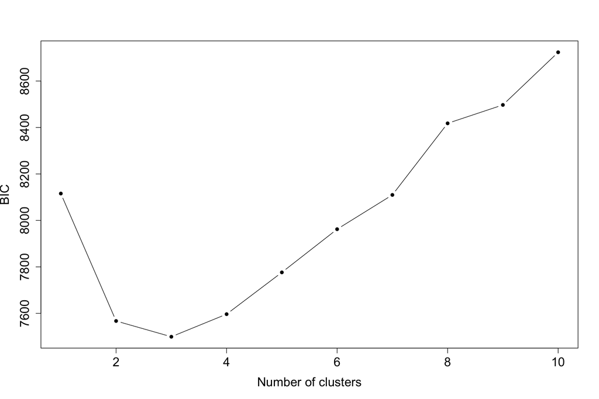

## Clustering Results

Looking at the breakdown of the Wealth Index across SES and Clusters, it looks as though the clustering is picking up on similar trends as the PCA. We see that cluster 1 has the “least” assets and cluster 3 has the “most” assets. This is good.

[output not shown]

[output cut: 396 more lines]